# Bank Data Analytics

```python
import pandas as pd
import numpy as np
import seaborn as sns
import matplotlib.pyplot as plt
import warnings
warnings.filterwarnings('ignore')
```

```python
df=pd.read_csv('Bank Marketing dataset.csv')
df
```

|  | age | job | marital | education | default | balance | housing | loan | contact | day | month | duration | campaign | pdays | previous | poutcome | Target |
| --- | --- | --- | --- | --- | --- | --- | --- | --- | --- | --- | --- | --- | --- | --- | --- | --- | --- |
| 0 | 58 | management | married | tertiary | no | 2143 | yes | no | unknown | 5 | may | 261 | 1 | -1 | 0 | unknown | no |
| 1 | 44 | technician | single | secondary | no | 29 | yes | no | unknown | 5 | may | 151 | 1 | -1 | 0 | unknown | no |
| 2 | 33 | entrepreneur | married | secondary | no | 2 | yes | yes | unknown | 5 | may | 76 | 1 | -1 | 0 | unknown | no |
| 3 | 47 | blue-collar | married | unknown | no | 1506 | yes | no | unknown | 5 | may | 92 | 1 | -1 | 0 | unknown | no |
| 4 | 33 | unknown | single | unknown | no | 1 | no | no | unknown | 5 | may | 198 | 1 | -1 | 0 | unknown | no |
| ... | ... | ... | ... | ... | ... | ... | ... | ... | ... | ... | ... | ... | ... | ... | ... | ... | ... |
| 45206 | 51 | technician | married | tertiary | no | 825 | no | no | cellular | 17 | nov | 977 | 3 | -1 | 0 | unknown | yes |
| 45207 | 71 | retired | divorced | primary | no | 1729 | no | no | cellular | 17 | nov | 456 | 2 | -1 | 0 | unknown | yes |
| 45208 | 72 | retired | married | secondary | no | 5715 | no | no | cellular | 17 | nov | 1127 | 5 | 184 | 3 | success | yes |
| 45209 | 57 | blue-collar | married | secondary | no | 668 | no | no | telephone | 17 | nov | 508 | 4 | -1 | 0 | unknown | no |
| 45210 | 37 | entrepreneur | married | secondary | no | 2971 | no | no | cellular | 17 | nov | 361 | 2 | 188 | 11 | other | no |

45211 rows × 17 columns

# Shape of the dataset

```python
print("No of rows:",df.shape[0])
print("No of cols:",df.shape[1])
```

```
No of rows: 45211
No of cols: 17
```

# Columns of the datset

```python
df.columns
```

```
Index(['age', 'job', 'marital', 'education', 'default', 'balance', 'housing',
       'loan', 'contact', 'day', 'month', 'duration', 'campaign', 'pdays',
       'previous', 'poutcome', 'Target'],
      dtype='object')
```

# Statistical Information

```python
df.describe()
```

|  | age | balance | day | duration | campaign | pdays | previous |
| --- | --- | --- | --- | --- | --- | --- | --- |
| count | 45211.000000 | 45211.000000 | 45211.000000 | 45211.000000 | 45211.000000 | 45211.000000 | 45211.000000 |
| mean | 40.936210 | 1362.272058 | 15.806419 | 258.163080 | 2.763841 | 40.197828 | 0.580323 |
| std | 10.618762 | 3044.765829 | 8.322476 | 257.527812 | 3.098021 | 100.128746 | 2.303441 |
| min | 18.000000 | -8019.000000 | 1.000000 | 0.000000 | 1.000000 | -1.000000 | 0.000000 |
| 25% | 33.000000 | 72.000000 | 8.000000 | 103.000000 | 1.000000 | -1.000000 | 0.000000 |
| 50% | 39.000000 | 448.000000 | 16.000000 | 180.000000 | 2.000000 | -1.000000 | 0.000000 |
| 75% | 48.000000 | 1428.000000 | 21.000000 | 319.000000 | 3.000000 | -1.000000 | 0.000000 |
| max | 95.000000 | 102127.000000 | 31.000000 | 4918.000000 | 63.000000 | 871.000000 | 275.000000 |

# Exploratory Data Analytics

```python
df.info()
```

```
<class 'pandas.core.frame.DataFrame'>
RangeIndex: 45211 entries, 0 to 45210
Data columns (total 17 columns):
 #   Column     Non-Null Count  Dtype
---  ------     --------------  -----
 0   age        45211 non-null  int64
 1   job        45211 non-null  object
 2   marital    45211 non-null  object
 3   education  45211 non-null  object
 4   default    45211 non-null  object
 5   balance    45211 non-null  int64
 6   housing    45211 non-null  object
 7   loan       45211 non-null  object
 8   contact    45211 non-null  object
 9   day        45211 non-null  int64
 10  month      45211 non-null  object
 11  duration   45211 non-null  int64
 12  campaign   45211 non-null  int64
 13  pdays      45211 non-null  int64
 14  previous   45211 non-null  int64
 15  poutcome   45211 non-null  object
 16  Target     45211 non-null  object
dtypes: int64(7), object(10)
memory usage: 5.9+ MB
```

# Observation

- All the columns are having proper data type

## Check irregularities in the data

```python
def irregularities(data):
    for col in data:
        print('*'*20,col,'*'*20)
        print(df[col].agg(['unique','nunique','count']))
        print('----------------------END----------------------------')
irregularities(df)
```

```
******************** age ********************
unique     [58, 44, 33, 47, 35, 28, 42, 43, 41, 29, 53, 5...
nunique                                                   77
count                                                  45211
Name: age, dtype: object
----------------------END----------------------------
******************** job ********************
unique     [management, technician, entrepreneur, blue-co...
nunique                                                   12
count                                                  45211
Name: job, dtype: object
----------------------END----------------------------
******************** marital ********************
unique     [married, single, divorced]
nunique                              3
count                            45211
Name: marital, dtype: object
----------------------END----------------------------
******************** education ********************
unique     [tertiary, secondary, unknown, primary]
nunique                                          4
count                                        45211
Name: education, dtype: object
----------------------END----------------------------
******************** default ********************
unique     [no, yes]
nunique            2
count          45211
Name: default, dtype: object
----------------------END----------------------------
******************** balance ********************
unique     [2143, 29, 2, 1506, 1, 231, 447, 121, 593, 270...
nunique                                                 7168
count                                                  45211
Name: balance, dtype: object
----------------------END----------------------------
******************** housing ********************
unique     [yes, no]
nunique            2
count          45211
```

[output cut: 47 more lines]

```
count                                                  45211
Name: previous, dtype: object
----------------------END----------------------------
******************** poutcome ********************
unique     [unknown, failure, other, success]
nunique                                     4
count                                   45211
Name: poutcome, dtype: object
----------------------END----------------------------
******************** Target ********************
unique     [no, yes]
nunique            2
count          45211
Name: Target, dtype: object
----------------------END----------------------------
```

### No irregularities in the data

```python
df.info()
```

```
<class 'pandas.core.frame.DataFrame'>
RangeIndex: 45211 entries, 0 to 45210
Data columns (total 17 columns):
 #   Column     Non-Null Count  Dtype
---  ------     --------------  -----
 0   age        45211 non-null  int64
 1   job        45211 non-null  object
 2   marital    45211 non-null  object
 3   education  45211 non-null  object
 4   default    45211 non-null  object
 5   balance    45211 non-null  int64
 6   housing    45211 non-null  object
 7   loan       45211 non-null  object
 8   contact    45211 non-null  object
 9   day        45211 non-null  int64
 10  month      45211 non-null  object
 11  duration   45211 non-null  int64
 12  campaign   45211 non-null  int64
 13  pdays      45211 non-null  int64
 14  previous   45211 non-null  int64
 15  poutcome   45211 non-null  object
 16  Target     45211 non-null  object
dtypes: int64(7), object(10)
memory usage: 5.9+ MB
```

# Check for empty strings

```python
def replace_empty_string(data):
    for col in data:
        df[col].replace(" ",np.nan,inplace=True)
replace_empty_string(df.select_dtypes(include='object'))
```

# Observation:

- The empty string(' ') which is an value for the pandas may consists in the data frame which are unable to identify by isnull() so it helps to replace with null

# Check for any missing values in the dataset

```python
df.isnull().sum()
```

```
age          0
job          0
marital      0
education    0
default      0
balance      0
housing      0
loan         0
contact      0
day          0
month        0
duration     0
campaign     0
pdays        0
previous     0
poutcome     0
Target       0
dtype: int64
```

# Observation

- **No null values** in the dataset

## Check for the duplicate

```python
df[df.duplicated()]
```

|  | age | job | marital | education | default | balance | housing | loan | contact | day | month | duration | campaign | pdays | previous | poutcome | Target |
| --- | --- | --- | --- | --- | --- | --- | --- | --- | --- | --- | --- | --- | --- | --- | --- | --- | --- |

# Observation

- **No duplicate rows** in the dataset

# Target Distribution

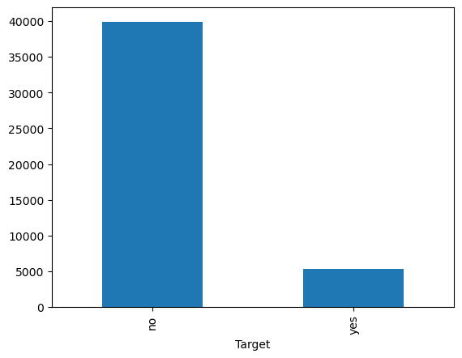

```python
df['Target'].value_counts().plot(kind='bar')
```

# Observation

- There is high-imbalance in the dataset
- We need to apply **SMOTE** technique to balance the classes

# Uni-Variant Non-visual Analysis

```python
def uni_variant_non_visual_num(data):
    for col in data:
        print("*"*20,col,'*'*20)
        print(df[col].agg(['min','max','mean','median','std','skew']))
        print('-'*20,'END','-'*20)
def uni_variant_non_visual_cat(data):
    for col in data:
        print("*"*20,col,'*'*20)
        print(df[col].agg(['count','unique','unique']))
        print("Value Counts:")
        print(df[col].value_counts())
        print('-'*20,'END','-'*20)
```

### Numerical Columns

```python
uni_variant_non_visual_num(df.select_dtypes(include='number'))
```

```
******************** age ********************
min       18.000000
max       95.000000
mean      40.936210
median    39.000000
std       10.618762
skew       0.684818
Name: age, dtype: float64
-------------------- END --------------------
******************** balance ********************
min        -8019.000000
max       102127.000000
mean        1362.272058
median       448.000000
std         3044.765829
skew           8.360308
Name: balance, dtype: float64
-------------------- END --------------------
******************** day ********************
min        1.000000
max       31.000000
mean      15.806419
median    16.000000
std        8.322476
skew       0.093079
Name: day, dtype: float64
-------------------- END --------------------
******************** duration ********************
min          0.000000
max       4918.000000
mean       258.163080
median     180.000000
std        257.527812
skew         3.144318
Name: duration, dtype: float64
-------------------- END --------------------
******************** campaign ********************
min        1.000000
max       63.000000
mean       2.763841
```

[output cut: 8 more lines]

```
mean       40.197828
median     -1.000000
std       100.128746
skew        2.615715
Name: pdays, dtype: float64
-------------------- END --------------------
******************** previous ********************
min         0.000000
max       275.000000
mean        0.580323
median      0.000000
std         2.303441
skew       41.846454
Name: previous, dtype: float64
-------------------- END --------------------
```

### Categorical Columns

```python
uni_variant_non_visual_cat(df.select_dtypes(include='object'))
```

```
******************** job ********************
count                                                 45211
unique    [management, technician, entrepreneur, blue-co...
unique    [management, technician, entrepreneur, blue-co...
Name: job, dtype: object
Value Counts:
job
blue-collar      9732
management       9458
technician       7597
admin.           5171
services         4154
retired          2264
self-employed    1579
entrepreneur     1487
unemployed       1303
housemaid        1240
student           938
unknown           288
Name: count, dtype: int64
-------------------- END --------------------
******************** marital ********************
count                           45211
unique    [married, single, divorced]
unique    [married, single, divorced]
Name: marital, dtype: object
Value Counts:
marital
married     27214
single      12790
divorced     5207
Name: count, dtype: int64
-------------------- END --------------------
******************** education ********************
count                                       45211
unique    [tertiary, secondary, unknown, primary]
unique    [tertiary, secondary, unknown, primary]
Name: education, dtype: object
Value Counts:
education
```

[output cut: 81 more lines]

```
other       1840
success     1511
Name: count, dtype: int64
-------------------- END --------------------
******************** Target ********************
count         45211
unique    [no, yes]
unique    [no, yes]
Name: Target, dtype: object
Value Counts:
Target
no     39922
yes     5289
Name: count, dtype: int64
-------------------- END --------------------
```

# Uni-Variant visual Analysis

```python
import math
def uni_variant_visual_num(data):
    num_cols = data.select_dtypes(include='number').columns
    n = len(num_cols)

    cols = 3
    rows = math.ceil(n / cols)

    plt.figure(figsize=(cols * 10, rows * 10))

    for i, col in enumerate(num_cols, start=1):
        plt.subplot(rows, cols, i)
        sns.histplot(data=data, x=col,kde=True)
        plt.title(f"Distribution of {col}")
        plt.xlabel(col)
        plt.ylabel("Frequency")
        plt.grid(True)

    # plt.tight_layout()
    plt.show()
```

### Numerical columns

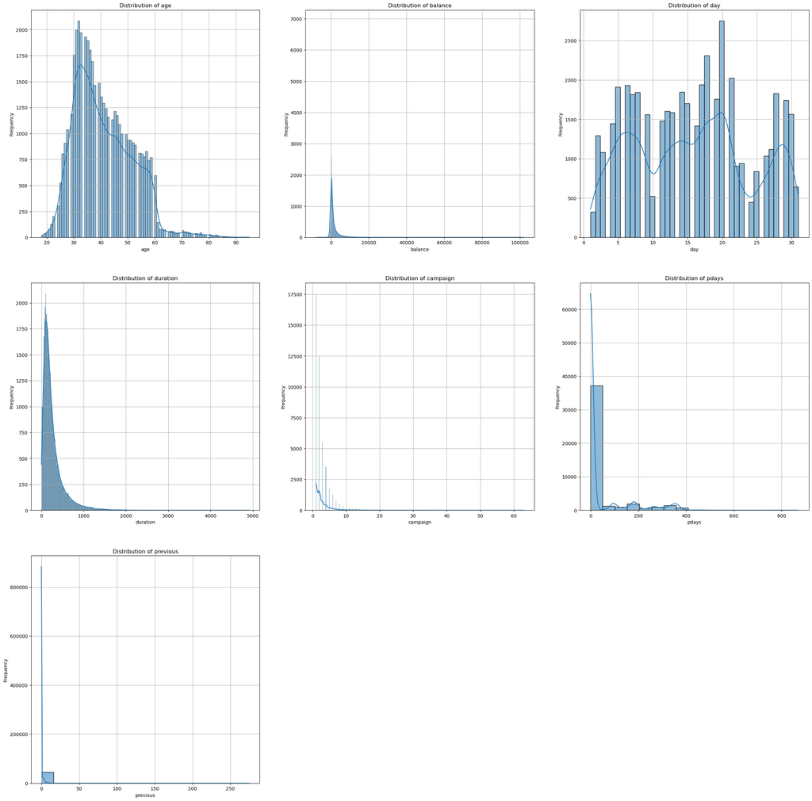

```python
uni_variant_visual_num(df)
```

### Categorical columns

```python
import math
def uni_variant_visual_cat(data):
    num_cols = data.select_dtypes(include='object').columns
    n = len(num_cols)

    cols = 3
    rows = math.ceil(n / cols)

    plt.figure(figsize=(cols * 10, rows * 10))

    for i, col in enumerate(num_cols, start=1):
        plt.subplot(rows, cols, i)
        sns.countplot(data=data, x=col)
        plt.title(f"Distribution of {col}")
        plt.xlabel(col)
        plt.ylabel("Frequency")
        plt.xticks(rotation=45)
        plt.legend()
        plt.grid(True)

    plt.show()
```

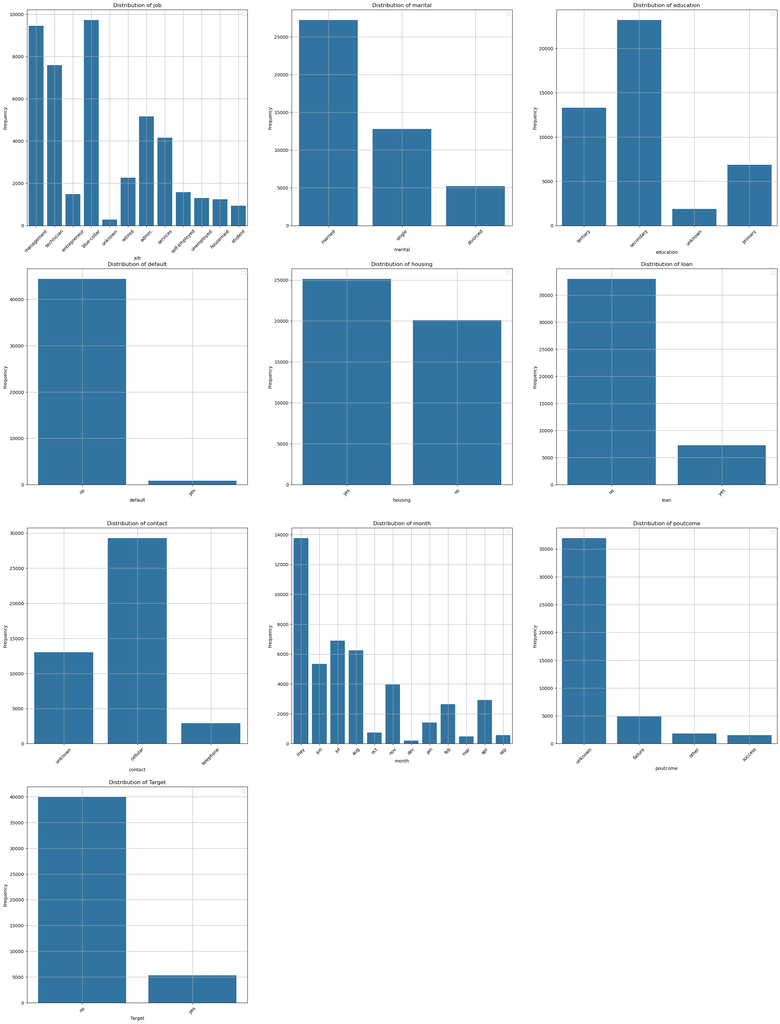

```python
uni_variant_visual_cat(df)
```

# Bi-variant Analysis

### Numerical Columns

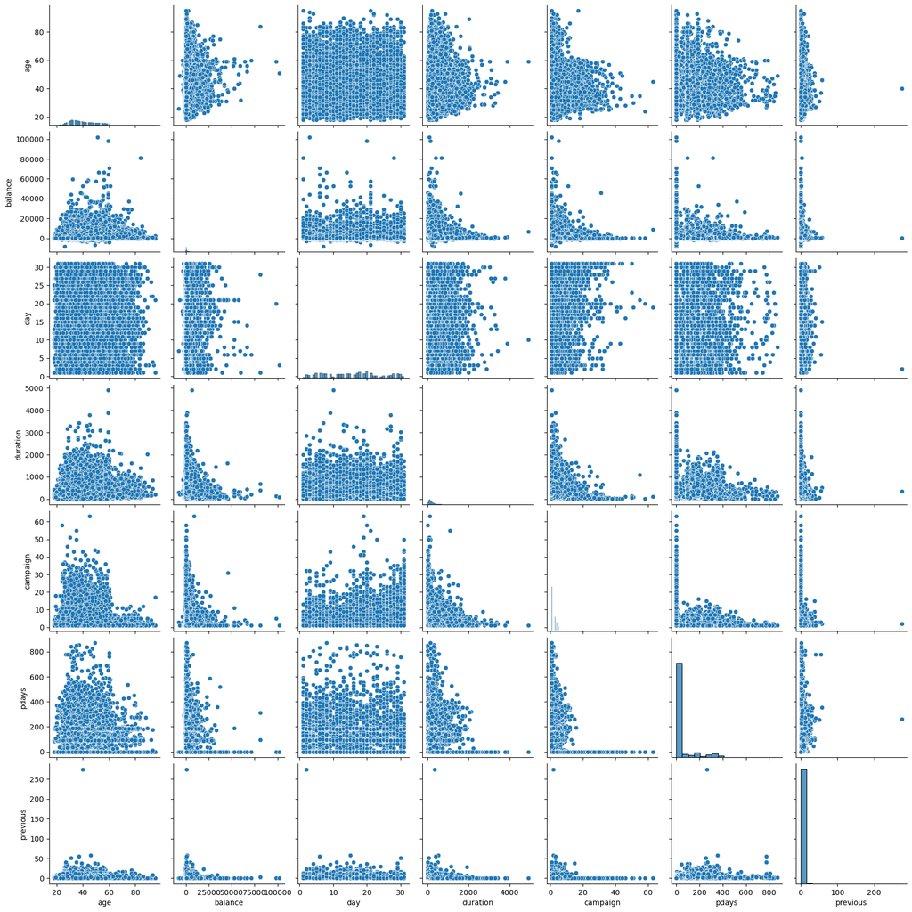

```python
sns.pairplot(df,diag_kind='hist')
```

### Categorical Columns

[figure not shown]

```python
import pandas as pd
import matplotlib.pyplot as plt
from itertools import combinations

def plot_bivariate_categorical_bar(df):
    # Step 1: Identify categorical columns
    cat_cols = df.select_dtypes(include=['object', 'category']).columns.tolist()
    combination = list(combinations(cat_cols, 2))

    # Step 2: Prepare subplots
    total = len(combination)
    ncols = 2
    nrows = (total + 1) // ncols
    fig, axes = plt.subplots(nrows=nrows, ncols=ncols, figsize=(15, 5 * nrows))
    axes = axes.flatten()

    # Step 3: Loop through combinations and plot
    for i, (col_x, col_y) in enumerate(combination):
        ct = pd.crosstab(df[col_x], df[col_y])
        ct.plot(kind='bar', ax=axes[i], legend=True)
        axes[i].set_title(f'{col_x} vs {col_y}')
        axes[i].set_xlabel(col_x)
        axes[i].set_ylabel('Count')

    # Hide unused axes
    for j in range(i + 1, len(axes)):
        fig.delaxes(axes[j])

    plt.tight_layout()
    plt.show()
plot_bivariate_categorical_bar(df)
```

### Num vs Target

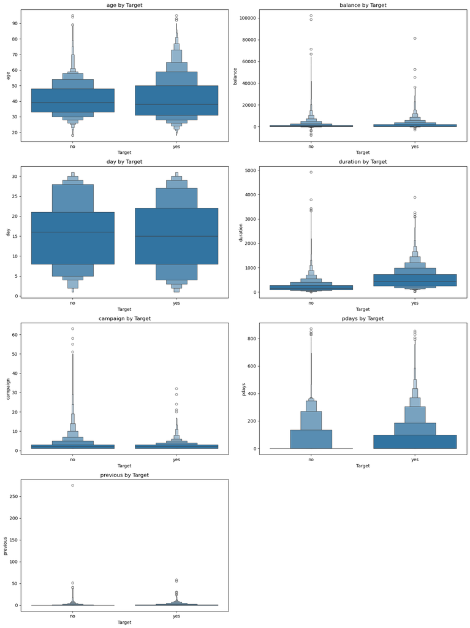

```python
import pandas as pd
import matplotlib.pyplot as plt
import seaborn as sns
from itertools import product

def plot_num_vs_cat_boxen(df):
    # Step 1: Select column types
    cat_cols = ['Target']
    num_cols = df.select_dtypes(include=['number']).columns.tolist()

    # Step 2: Generate all combinations
    combinations = list(product(num_cols, cat_cols))

    # Step 3: Subplot setup
    total = len(combinations)
    ncols = 2
    nrows = (total + 1) // ncols
    fig, axes = plt.subplots(nrows=nrows, ncols=ncols, figsize=(15, 5 * nrows))
    axes = axes.flatten()

    # Step 4: Loop through each (num, cat) and plot boxen
    for i, (num_col, cat_col) in enumerate(combinations):
        sns.boxenplot(data=df, x=cat_col, y=num_col, ax=axes[i])
        axes[i].set_title(f'{num_col} by {cat_col}')
        axes[i].set_xlabel(cat_col)
        axes[i].set_ylabel(num_col)

    # Step 5: Hide extra subplots
    for j in range(i + 1, len(axes)):
        fig.delaxes(axes[j])

    plt.tight_layout()
    plt.show()
plot_num_vs_cat_boxen(df)
```

# Separate the Input Features and Target class

```python
X=df.drop('Target',axis=1)
y=df['Target']
```

```python
X.head()
```

|  | age | job | marital | education | default | balance | housing | loan | contact | day | month | duration | campaign | pdays | previous | poutcome |
| --- | --- | --- | --- | --- | --- | --- | --- | --- | --- | --- | --- | --- | --- | --- | --- | --- |
| 0 | 58 | management | married | tertiary | no | 2143 | yes | no | unknown | 5 | may | 261 | 1 | -1 | 0 | unknown |
| 1 | 44 | technician | single | secondary | no | 29 | yes | no | unknown | 5 | may | 151 | 1 | -1 | 0 | unknown |
| 2 | 33 | entrepreneur | married | secondary | no | 2 | yes | yes | unknown | 5 | may | 76 | 1 | -1 | 0 | unknown |
| 3 | 47 | blue-collar | married | unknown | no | 1506 | yes | no | unknown | 5 | may | 92 | 1 | -1 | 0 | unknown |
| 4 | 33 | unknown | single | unknown | no | 1 | no | no | unknown | 5 | may | 198 | 1 | -1 | 0 | unknown |

```python
X.shape,y.shape
```

```
((45211, 16), (45211,))
```

```python
X.info()
```

```
<class 'pandas.core.frame.DataFrame'>
RangeIndex: 45211 entries, 0 to 45210
Data columns (total 16 columns):
 #   Column     Non-Null Count  Dtype
---  ------     --------------  -----
 0   age        45211 non-null  int64
 1   job        45211 non-null  object
 2   marital    45211 non-null  object
 3   education  45211 non-null  object
 4   default    45211 non-null  object
 5   balance    45211 non-null  int64
 6   housing    45211 non-null  object
 7   loan       45211 non-null  object
 8   contact    45211 non-null  object
 9   day        45211 non-null  int64
 10  month      45211 non-null  object
 11  duration   45211 non-null  int64
 12  campaign   45211 non-null  int64
 13  pdays      45211 non-null  int64
 14  previous   45211 non-null  int64
 15  poutcome   45211 non-null  object
dtypes: int64(7), object(9)
memory usage: 5.5+ MB
```